# Data Wrangling on Quarterly Workforce Indicators (QWI) Data

Yimin Guo

11/12/2021

## Introduction

Me and my former research adviser, Dr. Zhaochen He at Christopher Newport University, coauthored a paper that studies the impact of several anti-immigration laws issued in early 2010s on employment and income for Americans working legally in these states [draft available here](https://www.researchgate.net/publication/352661030_The_Labor_Market_Effect_of_State_Level_Anti-Immigration_Legislation_in_the_United_States). This research project uses the Quarterly Workforce Indicators (QWI) data, and following code chunks do the preparation part of the empirical analysis:

```r
library(tidyverse)
library(data.table)
library(RJDemetra)
library(htmltab)
library(tidycensus)
library(lubridate)
library(rlist)
library(doParallel)
library(foreach)
library(parallel)

setwd('E:/Github/proj1')
```

## Step 1: Select the Observations & Variables of Interest

Here is a preview of the raw QWI data:

```r
qwi = fread('qwi_naics2_eth_edu.csv')
# to save time and computing power, only select of subset of our data to demonstrate
qwi = qwi[industry == '00' & race == 'A0' & ethnicity == 'A0' & education == 'E0']
head(qwi,10)
```

```
##     geography industry sex agegrp race ethnicity education year quarter    Emp
##  1:      2013       00   0    A00   A0        A0        E0 2009       1    844
##  2:      2016       00   0    A00   A0        A0        E0 2009       1   3285
##  3:      2020       00   0    A00   A0        A0        E0 2009       1 143633
##  4:      2050       00   0    A00   A0        A0        E0 2009       1   5350
##  5:      2060       00   0    A00   A0        A0        E0 2009       1    522
##  6:      2068       00   0    A00   A0        A0        E0 2009       1    591
##  7:      2070       00   0    A00   A0        A0        E0 2009       1   1845
##  8:      2090       00   0    A00   A0        A0        E0 2009       1  30261
##  9:      2100       00   0    A00   A0        A0        E0 2009       1    638
## 10:      2105       00   0    A00   A0        A0        E0 2009       1    384
##       EmpS EmpTotal  HirA HirAS SepS FrmJbC FrmJbCS EarnS    Payroll
##  1:    754     1083   239    63   56     89       8  2705    7344977
##  2:   3092     4841  1555   159  126   1028      35  2796   32880949
##  3: 128225   166637 23004 13432 9817   1220    3592  4158 1758547289
##  4:   4628     6587  1237   632  439    -37     203  2493   40342661
##  5:    479      619    97    50   29     29      21  3434    5160227
##  6:    559      679    87    41   21     31      19  5132    8660429
##  7:   1645     2290   446   204  130     86      81  3034   16581626
##  8:  26831    35786  5525  2827 2240    549     581  3440  305479243
##  9:    581      765   127    78   37     32      41  2615    4954830
## 10:    349      474    90    39   22     14      17  1999    2301836
```

We are only interested in certain observations and variables, the chunk below does the selection:

```r
# create a date variable called yq
qwi = qwi[, yq := paste(year,'-',quarter)][, dt := yq(yq)]

# extract the variables of interest
qwi = qwi[,statefipsn := floor(geography/1000)][,cntyfipsn := geography - statefipsn*1000]
qwi = qwi[, c("dt","geography","statefipsn","cntyfipsn","industry",
              "race","ethnicity","education","Emp","HirA","HirAS",
              "FrmJbC","EarnS"), with = F]
names(qwi)[2] = 'geo'

# select of states/counties of interest
statelist = c(18,26,17,21,39,4,32,8,35,6,
              49,32,16,56,8,1,12,28,47,13,
              37,12,47,45,37)
qwi = qwi[statefipsn %in% statelist]
qwi = unique(qwi)

# convert Some Variabes to Numeric
varnames = c('Emp', 'HirA', 'HirAS', 'FrmJbC', 'EarnS')
qwi = qwi[, (varnames) := lapply(.SD, as.numeric), .SDcols = varnames]

# reshape the table to long form
id.vars = c('dt', 'geo','industry', 'race', 'ethnicity', 'education', 'statefipsn', 'cntyfipsn')
qwi = melt(qwi, id.vars = id.vars)
head(qwi,10)
```

```
##             dt  geo industry race ethnicity education statefipsn cntyfipsn
##  1: 2009-01-01 1001       00   A0        A0        E0          1         1
##  2: 2009-01-01 1003       00   A0        A0        E0          1         3
##  3: 2009-01-01 1005       00   A0        A0        E0          1         5
##  4: 2009-01-01 1007       00   A0        A0        E0          1         7
##  5: 2009-01-01 1009       00   A0        A0        E0          1         9
##  6: 2009-01-01 1011       00   A0        A0        E0          1        11
##  7: 2009-01-01 1013       00   A0        A0        E0          1        13
##  8: 2009-01-01 1015       00   A0        A0        E0          1        15
##  9: 2009-01-01 1017       00   A0        A0        E0          1        17
## 10: 2009-01-01 1019       00   A0        A0        E0          1        19
##     variable value
##  1:      Emp 11174
##  2:      Emp 56894
##  3:      Emp  9371
##  4:      Emp  3604
##  5:      Emp  8500
##  6:      Emp  2960
##  7:      Emp  6203
##  8:      Emp 42561
##  9:      Emp  7083
## 10:      Emp  4872
```

## Step 2: Ajusted Seasonality

The time series (e.g., Emp for total employment of a county in a certain quarter) have seasonal fluctuations, here we use RJDemetra package to smooth the seasonal swing:

```r
# this is the seasonality adjustment function:
adjust = function(x) {
  z = ts(x, start = 2009, frequency = 4)
  z = tramoseats(z, spec = "RSA5")
  z = z$final$series[,2]
  return(as.numeric(z))
}
```

Here we construct a table called `dir_all` in which each observation specifies a certain time series:

```r
# INPUT:
# breakdown by race & eth
naics = unique(qwi$industry)
g = unique(qwi$geo)
edu = unique(qwi$education)
r = unique(qwi$race)
eth = unique(qwi$ethnicity)
var = unique(qwi$variable)

dir_1 = as.data.table(expand.grid(geo = g, race = r, ethnicity = eth, industry = naics,
                                  education = 'E0', variable = var))
# breakdown by edu, but less EO, which is included in dir_1
dir_2 = as.data.table(expand.grid(geo = g, race = 'A0', ethnicity = 'A0', industry = naics,
                                  education = edu[2:6], variable = var))
dir_all = rbind(dir_1, dir_2)
dir_all = dir_all[1:1000] # again, this is to save time since it's just for demonstration
dir_all$tsid = 1:nrow(dir_all)
head(dir_all,10)
```

```
##      geo race ethnicity industry education variable tsid
##  1: 1001   A0        A0       00        E0      Emp    1
##  2: 1003   A0        A0       00        E0      Emp    2
##  3: 1005   A0        A0       00        E0      Emp    3
##  4: 1007   A0        A0       00        E0      Emp    4
##  5: 1009   A0        A0       00        E0      Emp    5
##  6: 1011   A0        A0       00        E0      Emp    6
##  7: 1013   A0        A0       00        E0      Emp    7
##  8: 1015   A0        A0       00        E0      Emp    8
##  9: 1017   A0        A0       00        E0      Emp    9
## 10: 1019   A0        A0       00        E0      Emp   10
```

Here is the parallel loop that does the seasonality adjustment:

```r
# divide the list into smaller lists
nchunks = 10
chunksize = ceiling(nrow(dir_all)/nchunks)
dir_all[, chunk := rep(1:nchunks, each = chunksize)[1:nrow(dir_all)]]

# specify the computing power we want to use
setkey(qwi, geo, race, ethnicity, industry, education, variable)
ncore = 6
setDTthreads(2)
dirpost = NULL


# ADJUSTMENT LOOP:
for (j in 1:nchunks) {

  dir = dir_all[chunk == j]
  start_time = Sys.time()

  # preload data into a giant list
  l.raw = list()
  l.date = list()

  for (i in 1:nrow(dir)) {
    if (i %% 10000 == 0) { print(i) }
    # uses key to extract time series
    z = qwi[list(dir[i, geo], dir[i, race], dir[i, ethnicity],
                 dir[i, industry], dir[i, education], dir[i, variable]), .(value,dt)]
    l.raw[[i]] = z$value
    l.date[[i]] = z$dt
  }

  # run adjustment in parallel
  start_time = Sys.time()
  try(file.remove(paste0('adj/logs/chunk_', j, '.txt')))
  cl = makePSOCKcluster(ncore, outfile = paste0('adj/logs/chunk_', j, '.txt'))
  registerDoParallel(cl)
  adj_out =
    tryCatch({
      foreach(series = l.raw, date = l.date, i = icount(),
              .packages = c('foreach', 'data.table', 'RJDemetra'),
              .errorhandling = 'pass'
      ) %dopar% {
        info = dir[i]
        series_adj = adjust(series)
        identical = identical(series, series_adj)
        samelength = length(series) == length(series_adj)
        if (samelength) {
          outdt = data.table(dt = date,
                             geo = info[, geo],
                             race = info[, race],
                             ethnicity = info[, ethnicity],
                             industry = info[, industry],
                             education = info[, education],
                             variable = info[, variable],
                             tsid = info[, tsid],
                             value = series,
                             value_adj = series_adj)
        }
        cat(i, '\n') # record iteration number
        res = list(chunk = j, row = i, identical = identical, samelength = samelength, outdt=outdt)
        return(res)
      }
    }, error = function(e) {return(e)})
  stopCluster(cl)

  # error reporting
  # report parallel loop error
  dir[, error1 := 'good']
  if ('error' %in% class(adj_out)) {
    dir[, error1 := paste0(as.character(adj_out), collapse = '_')]
  }

  dir[, error2 := 'good']
  for (i in 1:length(adj_out)) {
    if ('error' %in% class(adj_out[[i]])) {
      dir[i, 'error2'] = paste0(as.character(adj_out[[i]]), collapse = '_')
    }
  }

  saveRDS(adj_out, file = paste0('adj/adj_out_chunk_', j, '.rds'))
  fwrite(dir, file = paste0('adj/dir_chunk_', j, '.csv'))

}

qwi_adj = NULL
for (i in 1:(nchunks)) {
  #i = 1
  chunk = readRDS(paste0('adj/adj_out_chunk_', i, '.rds'))
  z1 = unlist(lapply(chunk, length)) == 5 # Items with length !=5 are erroneous
  chunk_clean = chunk[z1]
  z2 = unlist(lapply(chunk_clean, '[[', 'samelength')) # Items w/ samelength = F are erroneous #***
  chunk_clean = chunk_clean[z2]
  qwi_adj_chunk = lapply(chunk_clean, '[[', 'outdt')
  qwi_adj_chunk = rbindlist(qwi_adj_chunk)
  qwi_adj = rbind(qwi_adj, qwi_adj_chunk)
}
head(qwi_adj, 10)
```

```
##             dt  geo race ethnicity industry education variable tsid value
##  1: 2009-01-01 1001   A0        A0       00        E0      Emp    1 11174
##  2: 2009-04-01 1001   A0        A0       00        E0      Emp    1 11307
##  3: 2009-07-01 1001   A0        A0       00        E0      Emp    1 11101
##  4: 2009-10-01 1001   A0        A0       00        E0      Emp    1 11064
##  5: 2010-01-01 1001   A0        A0       00        E0      Emp    1 10908
##  6: 2010-04-01 1001   A0        A0       00        E0      Emp    1 11178
##  7: 2010-07-01 1001   A0        A0       00        E0      Emp    1 10991
##  8: 2010-10-01 1001   A0        A0       00        E0      Emp    1 11096
##  9: 2011-01-01 1001   A0        A0       00        E0      Emp    1 10824
## 10: 2011-04-01 1001   A0        A0       00        E0      Emp    1 11279
##     value_adj
##  1:  11271.93
##  2:  11157.58
##  3:  11172.11
##  4:  11049.40
##  5:  11019.77
##  6:  11028.59
##  7:  11048.17
##  8:  11033.57
##  9:  10980.97
## 10:  11127.88
```

Here is an example of raw time series vs. adjusted time series:

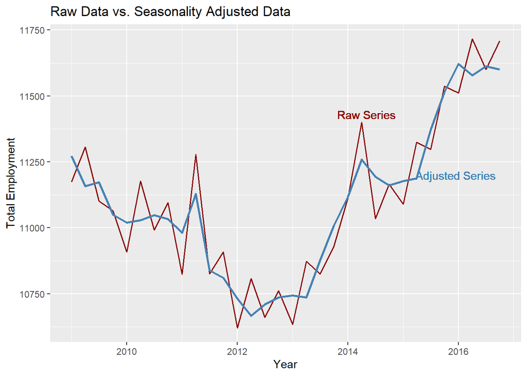

```r
dat = qwi_adj[geo == 1001 & race == 'A0' &
            ethnicity == 'A0' & education == 'E0' &
            industry == '00',c('dt','value','value_adj')]
dat$dt = as.Date(dat$dt)
ggplot(dat, aes(x = dt)) +
  geom_line(aes(y = value), color ="darkred", size = 0.7) +
  geom_line(aes(y = value_adj), color="steelblue", size=1) +
  labs(title="Raw Data vs. Seasonality Adjusted Data",
       y="Total Employment",
       x="Year") +
  geom_text(aes(x = as.Date("2014-05-07"), y = 11430, label = "Raw Series"), color = 'darkred') +
  geom_text(aes(x = as.Date("2015-12-14"), y = 11200, label = "Adjusted Series"), color = 'steelblue')
```

## Step 3: Reshape The Data

Right now all the raw time series (i.e., `Emp` for total employment, `EarnS` for earnings, etc.) are stacked together, and all the adjusted time series are stacked together. The chunk below unstack the data for us, making `Emp`, `Emp_adjusted`, `EarnS`, `EarnS_adjusted`, etc. each occupies a column:

```r
qwiLong = melt(qwi_adj, id.vars = c('dt','geo','race','ethnicity','industry','education','variable'),
               variable.name = 'adj', measure.vars = c('value', 'value_adj', 'tsid'))
qwiLong[adj == 'value', adj := '']
qwiLong[adj == 'value_adj', adj := '_adjusted']
qwiLong[adj == 'tsid', adj := '_tsid']
qwiLong = qwiLong[, vars := paste0(variable, adj)]
qwiLong = qwiLong[, c("dt","geo","race","ethnicity","industry","education","vars","value"), with = F]
qwiWide = dcast(qwiLong, dt + geo + race + ethnicity + industry + education ~ vars, value.var = 'value')
qwiWide = qwiWide[, c("year","month","date") := tstrsplit(dt, "-")]
qwiWide$year = as.numeric(qwiWide$year)
qwiWide = subset(qwiWide, select = -c(month,date))
head(qwiWide, 10)
```

```
##             dt  geo race ethnicity industry education   Emp Emp_adjusted
##  1: 2009-01-01 1001   A0        A0       00        E0 11174    11271.925
##  2: 2009-01-01 1003   A0        A0       00        E0 56894    59145.730
##  3: 2009-01-01 1005   A0        A0       00        E0  9371     9371.000
##  4: 2009-01-01 1007   A0        A0       00        E0  3604     3598.512
##  5: 2009-01-01 1009   A0        A0       00        E0  8500     8542.074
##  6: 2009-01-01 1011   A0        A0       00        E0  2960     3037.754
##  7: 2009-01-01 1013   A0        A0       00        E0  6203     6280.887
##  8: 2009-01-01 1015   A0        A0       00        E0 42561    42954.325
##  9: 2009-01-01 1017   A0        A0       00        E0  7083     7145.445
## 10: 2009-01-01 1019   A0        A0       00        E0  4872     4939.804
##     Emp_tsid year
##  1:        1 2009
##  2:        2 2009
##  3:        3 2009
##  4:        4 2009
##  5:        5 2009
##  6:        6 2009
##  7:        7 2009
##  8:        8 2009
##  9:        9 2009
## 10:       10 2009
```

*Note: in the sample output above, we only see* `Emp` *and* `Emp_adjusted` *but not the other time series variables. This is because we only run the code on a small subset of QWI since this is just a demonstration. Should we pass the entire QWI to the chunks above, we will obtain many more co-variates in the output.*